# 1. Convolution

# 3. Lab: CNN with TensorFlow (MNIST)

```python
from IPython.display import YouTubeVideo
YouTubeVideo('cr2fz5A2MXQ?si=df-ux84Q096QpMIc&amp;start=726', width = "560", height = "315")
```

[video not shown]

We will once again use the MNIST dataset to build a multiclass classifier that can identify whether an image belongs to one of the digits: 0 through 9. This time, however, the classifier will be implemented using a Convolutional Neural Network (CNN).

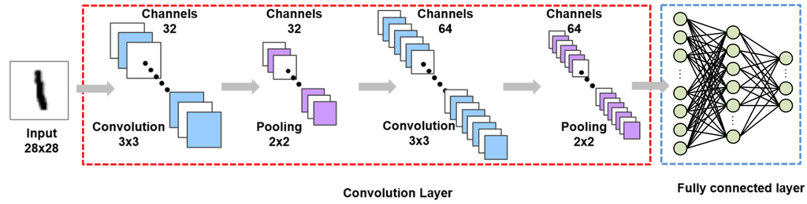

Note:

- This example is intended solely to demonstrate how to implement CNN in Python based on the provided structure.
- The hyperparameters of the above network have not been optimized.

**Load MNIST Data**

```python
import tensorflow as tf
import numpy as np
import matplotlib.pyplot as plt
```

```python
mnist = tf.keras.datasets.mnist

(train_x, train_y), (test_x, test_y) = mnist.load_data()

train_x, test_x = train_x/255.0, test_x/255.0
```

```
Downloading data from https://storage.googleapis.com/tensorflow/tf-keras-datasets/mnist.npz
11490434/11490434 ━━━━━━━━━━━━━━━━━━━━ 1s 0us/step
```

```python
train_x = train_x.reshape((train_x.shape[0], 28, 28, 1))
test_x = test_x.reshape((test_x.shape[0], 28, 28, 1))
```

**Define an CNN Structure**

```python
model = tf.keras.models.Sequential([
    tf.keras.layers.Input(shape = (28, 28, 1)),

    tf.keras.layers.Conv2D(filters = 32,
                          kernel_size = (3,3),
                          activation = 'relu',
                          padding = 'SAME'),

    tf.keras.layers.MaxPool2D((2,2)),

    tf.keras.layers.Conv2D(filters = 64,
                          kernel_size = (3,3),
                          activation = 'relu',
                          padding = 'SAME'),

    tf.keras.layers.MaxPool2D((2,2)),

    tf.keras.layers.Flatten(),

    tf.keras.layers.Dense(units = 128, activation = 'relu'),

    tf.keras.layers.Dense(units = 10, activation = 'softmax')
])
```

**Optimizer and Loss**

```python
model.compile(optimizer = 'adam',
              loss = 'sparse_categorical_crossentropy',
              metrics = ['accuracy'])
```

**Training**

```python
model.fit(train_x, train_y, batch_size = 50, epochs = 3)
```

```
1200/1200 ━━━━━━━━━━━━━━━━━━━━ 7s 2ms/step - accuracy: 0.8989 - loss: 0.3225
1200/1200 ━━━━━━━━━━━━━━━━━━━━ 3s 3ms/step - accuracy: 0.9860 - loss: 0.0455
1200/1200 ━━━━━━━━━━━━━━━━━━━━ 3s 3ms/step - accuracy: 0.9901 - loss: 0.0301
```

```
<keras.src.callbacks.history.History at 0x7de3997a62d0>
```

**Testing or Evaluating**

```python
test_loss, test_acc = model.evaluate(test_x, test_y)
```

```
313/313 ━━━━━━━━━━━━━━━━━━━━ 2s 4ms/step - accuracy: 0.9854 - loss: 0.0432
```

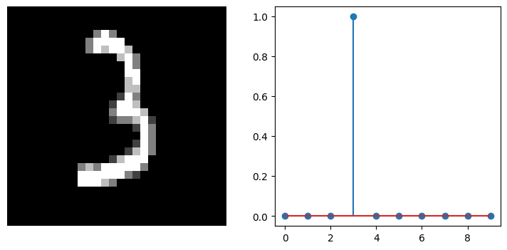

```
Prediction : 3
```

```python
test_img = test_x[[1495]]

predict = model.predict(test_img, verbose = 0)
mypred = np.argmax(predict, axis = 1)

plt.figure(figsize = (9, 4))

plt.subplot(1,2,1)
plt.imshow(test_img.reshape(28, 28), 'gray')
plt.axis('off')
plt.subplot(1,2,2)
plt.stem(predict[0])
plt.show()

print('Prediction : {}'.format(mypred[0]))
```

# 4. Lab: CNN with TensorFlow (Steel Surface Defects)

Having explored the implementation of a CNN using the MNIST dataset - a relatively simple and well-structured benchmark - we now turn our attention to a more realistic and practical engineering problem. In this case, we will consider the NEU Surface Defect Database (NEU), which contains images of steel surface defects commonly encountered in industrial applications.

- [NEU](https://pmc.ncbi.nlm.nih.gov/articles/PMC8007367/) steel surface defects
- To classify defects images into 6 classes

Download NEU steel surface defects images and labels

- [NEU train images](https://drive.google.com/file/d/18GFngBUJplDeA99sglTDxieLP_ZZAXzV/view?usp=drive_link)
- [NEU train labels](https://drive.google.com/file/d/1ZJmg7fuExCIJtlUBcbm0oT7jMbGe_MBE/view?usp=drive_link)
- [NEU test images](https://drive.google.com/file/d/1FgBff8_oZl1lQnfoCk2_gPaHK8QcImr2/view?usp=sharing)
- [NEU test labels](https://drive.google.com/file/d/1xV7XDfqtnHR7on-NL89rrBmNfcBp6UYu/view?usp=sharing)

**Training**

```python
from google.colab import drive
drive.mount('/content/drive')
```

```python
# Change file paths if necessary

train_x = np.load('/content/drive/MyDrive/DL/DL_data/NEU_train_imgs.npy')
train_y = np.load('/content/drive/MyDrive/DL/DL_data/NEU_train_labels.npy')

test_x = np.load('/content/drive/MyDrive/DL/DL_data/NEU_test_imgs.npy')
test_y = np.load('/content/drive/MyDrive/DL/DL_data/NEU_test_labels.npy')
```

```python
print(train_x.shape)
print(train_y.shape)
```

```
(1500, 200, 200, 1)
(1500,)
```

```python
print(test_x.shape)
print(test_y.shape)
```

```
(300, 200, 200, 1)
(300,)
```

```python
model = tf.keras.models.Sequential([
    tf.keras.layers.Input(shape = (200, 200, 1)),

    tf.keras.layers.Conv2D(filters = 32,
                           kernel_size = (3,3),
                           activation = 'relu',
                           padding = 'SAME'),

    tf.keras.layers.MaxPool2D((2,2)),

    tf.keras.layers.Conv2D(filters = 64,
                           kernel_size = (3,3),
                           activation = 'relu',
                           padding = 'SAME'),

    tf.keras.layers.MaxPool2D((2,2)),

    tf.keras.layers.Conv2D(filters = 128,
                           kernel_size = (3,3),
                           activation = 'relu',
                           padding = 'SAME'),

    tf.keras.layers.MaxPool2D((2,2)),

    tf.keras.layers.Flatten(),

    tf.keras.layers.Dense(units = 128, activation = 'relu'),

    tf.keras.layers.Dense(units = 6, activation = 'softmax')
])
```

```python
model.compile(optimizer = 'adam',
              loss = 'sparse_categorical_crossentropy',
              metrics = ['accuracy'])
```

```python
model.fit(train_x, train_y, batch_size = 50, epochs = 10)
```

```
30/30 ━━━━━━━━━━━━━━━━━━━━ 7s 53ms/step - accuracy: 0.2002 - loss: 1.9501
30/30 ━━━━━━━━━━━━━━━━━━━━ 2s 53ms/step - accuracy: 0.4500 - loss: 1.2660
30/30 ━━━━━━━━━━━━━━━━━━━━ 2s 53ms/step - accuracy: 0.7512 - loss: 0.7029
30/30 ━━━━━━━━━━━━━━━━━━━━ 2s 53ms/step - accuracy: 0.7197 - loss: 0.8572
30/30 ━━━━━━━━━━━━━━━━━━━━ 2s 54ms/step - accuracy: 0.8826 - loss: 0.3399
30/30 ━━━━━━━━━━━━━━━━━━━━ 2s 54ms/step - accuracy: 0.9219 - loss: 0.2099
30/30 ━━━━━━━━━━━━━━━━━━━━ 2s 54ms/step - accuracy: 0.9442 - loss: 0.1648
30/30 ━━━━━━━━━━━━━━━━━━━━ 2s 54ms/step - accuracy: 0.9145 - loss: 0.2472
30/30 ━━━━━━━━━━━━━━━━━━━━ 2s 54ms/step - accuracy: 0.9358 - loss: 0.1762
30/30 ━━━━━━━━━━━━━━━━━━━━ 2s 54ms/step - accuracy: 0.8697 - loss: 0.4285
```

```
<keras.src.callbacks.history.History at 0x7de382793650>
```

**Testing or Evaluating**

```python
test_loss, test_acc = model.evaluate(test_x, test_y)
```

```
10/10 ━━━━━━━━━━━━━━━━━━━━ 2s 92ms/step - accuracy: 0.9138 - loss: 0.2473
```

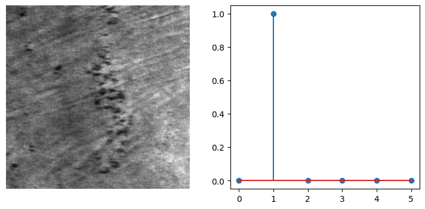

```
Prediction : rolled-in scale
True Label : rolled-in scale
```

```python
name = ['scratches', 'rolled-in scale', 'pitted surface', 'patches', 'inclusion', 'crazing']

idx = np.random.choice(test_x.shape[0], 1)
test_img = test_x[idx]
test_label = test_y[idx]

predict = model.predict(test_img, verbose = 0)
mypred = np.argmax(predict, axis = 1)

plt.figure(figsize = (9, 4))
plt.subplot(1,2,1)
plt.imshow(test_img.reshape(200, 200), 'gray')
plt.axis('off')
plt.subplot(1,2,2)
plt.stem(predict[0])
plt.show()

print('Prediction : {}'.format(name[mypred[0]]))
print('True Label : {}'.format(name[test_label[0]]))
```

```python
%%javascript
$.getScript('https://kmahelona.github.io/ipython_notebook_goodies/ipython_notebook_toc.js')
```